# 机器学习与因果推断 - 第十讲：因果森林——异质性分析与政策学习

从估计到评估与决策：完整讲义

作者

单位

陈志远

中国人民大学商学院

发布于

2026年5月26日

# 1 引言

在第九讲中，我们学习了广义随机森林（GRF）框架——利用 Robinson 变换消除混杂、通过因果森林自适应地学习核权重，并利用渐近正态性理论进行逐点推断。GRF 让我们能够灵活地估计条件平均处理效应（CATE）$\tau(x) = E[Y(1) - Y(0) \mid X = x]$。

然而，*获得一个 CATE 估计只是第一步*。本讲聚焦三个递进的后续问题：

1. **检验**：估计到的异质性是真实的，还是过拟合产生的统计噪声？
2. **评估**：如果异质性真实存在，我们的 CATE 排序有多好？
3. **决策**：如何将 CATE 估计转化为最优处理分配规则？

这三个问题的核心参考文献包括：Chernozhukov et al. (2023) 关于 BLP 和 GATES 的通用检验框架、Yadlowsky et al. (2021) 关于 RATE/AUTOC/Qini 的排序评估理论、以及 Athey & Wager (2021) 关于最优政策学习的经典论文。

## 1.1 上节课回顾

在第九讲中，我们建立了以下关键概念：

- **异质性处理效应**：CATE $\tau(x) = E[Y(1) - Y(0) \mid X = x]$ 刻画处理效应随个体特征的变化。ATE 只是 $\tau(x)$ 在群体上的平均，掩盖了丰富的异质性信息。
- **因果树的思想**：与传统 CART 最大化 $Y$ 的可预测性不同，因果树最大化子节点间 *处理效应差异*。这一思想是理解因果森林的基础。
- **GRF 框架**：先通过 Robinson 变换 $\tilde{Y} = Y - m(X)$、$\tilde{T} = T - e(X)$ 去除混杂，再用因果森林对 $(\tilde{Y}, \tilde{T})$ 学习自适应权重，最终通过加权局部矩方程求解 CATE。
- **统计推断**：GRF 在正则条件下具有渐近正态性，honesty 机制保证逐点推断有效。诚实分裂确保了估计的无偏性。

本讲在此基础上，转向 CATE 估计的 *验证、评估和应用*。

# 2 第一部分：从估计到评估——过拟合陷阱

## 2.1 为什么不能直接信任 CATE 估计

机器学习模型非常灵活，这既是其优势也是其风险。一个关键的陷阱在于：

**警告过拟合陷阱**

即使真实的处理效应完全均匀（不存在异质性），灵活的 ML 模型也可以在训练数据中拟合出看似显著的异质性模式。这种”虚假异质性”会误导决策。

考虑以下场景：

- 一位研究者使用因果森林估计了就业培训项目的 CATE
- 模型显示年轻男性的效应为 +8 分，年长女性的效应为 +2 分
- 基于此推荐对年轻男性优先提供培训名额
- 但如果这个异质性只是噪声拟合的结果，就会导致资源错配

### 2.1.1 预测建模 vs 因果建模的验证差异

在预测建模中，我们有清晰的验证框架：

| 阶段 | 预测建模 | 因果建模 |
| --- | --- | --- |
| 模型训练 | 拟合 $\hat{f}(x)$ | 估计 $\hat{\tau}(x)$（上节课） |
| 模型验证 | 测试集 MSE、交叉验证 | **异质性检验 + 排序评估**（本讲前半） |
| 模型部署 | 预测未来观测 | **政策学习与分配规则**（本讲后半） |

因果建模的验证困难在于：我们 *永远无法同时观测* $Y(1)$ 和 $Y(0)$，因此无法直接计算 $\hat{\tau}(x)$ 的预测误差。这要求我们发展专门的评估方法。

## 2.2 三步框架

本讲围绕三个递进问题展开，形成完整的”估计 → 验证 → 决策”管道：

**注记从估计到决策的三步框架**

1. **检验**（Is it real?）：估计到的异质性是真实的吗？→ BLP 检验
2. **评估**（How good?）：CATE 模型的排序有多好？→ TOC、AUTOC、Qini 曲线
3. **决策**（What to do?）：如何将估计转化为最优分配规则？→ 政策树

# 3 第二部分：异质性检验——BLP 与 GATES

## 3.1 BLP 检验的核心思想

最佳线性预测器（Best Linear Predictor, BLP）由 Chernozhukov, Demirer, Duflo & Fernández-Val (2023) 提出，其核心思路非常直观：

*如果 $\hat{\tau}(x)$ 真的捕捉了异质性，那么用它来预测真实 $\tau(x)$ 时，应该有正的线性关系。*

形式化地，考虑 $\tau(X)$ 对 $\hat{\tau}(X)$ 的最佳线性预测：

$$\tau_{BLP}(x) = \alpha_0 + \alpha_1 (\hat{\tau}(x) - \bar{\hat{\tau}})$$

其中：

- $\alpha_0 = E[\tau(X)]$：平均处理效应（ATE）
- $\alpha_1 = \frac{\text{Cov}(\tau(X), \hat{\tau}(X))}{\text{Var}(\hat{\tau}(X))}$：异质性信号强度

### 3.1.1 理解 $\alpha_1$ 的含义

$\alpha_1$ 的值揭示了模型估计质量：

| $\alpha_1$ 范围 | 含义 |
| --- | --- |
| $\alpha_1 \approx 0$ | $\hat{\tau}(x)$ 的变化与真实异质性无关，只是噪声 |
| $0 < \alpha_1 < 1$ | 模型捕捉到了部分真实异质性，但信号被稀释 |
| $\alpha_1 \approx 1$ | 模型完美校准，$\hat{\tau}(x)$ 的线性变化等于 $\tau(x)$ 的变化 |
| $\alpha_1 > 1$ | 理论上不常见，可能是模型低估了 CATE 的方差 |

## 3.2 BLP 回归方程

如何在实际数据中估计 $\alpha_0$ 和 $\alpha_1$？Chernozhukov et al. (2023) 的巧妙之处在于，他们将 BLP 转化为一个标准的 OLS 回归问题。

在 *独立的测试样本* 上运行如下回归：

$$Y_i = \gamma' X_i + \alpha_0 (D_i - e(X_i)) + \alpha_1 (D_i - e(X_i))(\hat{\tau}(X_i) - \bar{\hat{\tau}}) + \varepsilon_i$$

其中：

- $D_i$ 是处理状态（0 或 1）
- $e(X_i) = P(D_i = 1 \mid X_i)$ 是倾向得分
- $\gamma' X_i$ 控制了基线结果的异质性
- $(D_i - e(X_i))$ 是中心化的处理指标
- $\hat{\tau}(X_i) - \bar{\hat{\tau}}$ 是中心化的 CATE 估计

**警告样本分割至关重要**

训练集用于估计 $\hat{\tau}(x)$，测试集用于运行 BLP 回归。如果用同一份数据做估计和检验，过拟合会导致虚假的显著性结果——即使模型只拟合了噪声，$\alpha_1$ 也可能显著偏离零。

### 3.2.1 两个检验统计量

BLP 回归自然产生两个检验：

| 检验 | 原假设 | 含义 |
| --- | --- | --- |
| **校准检验** | $H_0: \alpha_0 = 0$ | ATE 是否显著不为零 |
| **异质性检验** | $H_0: \alpha_1 = 0$ | CATE 模型是否捕捉了真实异质性 |

对于异质性分析而言，核心检验是 $\alpha_1$：

- $\alpha_1$ 的 p-value 很小 → 存在统计显著的异质性，模型捕捉到了
- $\alpha_1$ 的 p-value 较大 → 无法拒绝”无异质性”的假设

## 3.3 Python 实现：BLP 检验

下面通过模拟实验演示 BLP 检验的完整流程。

### 3.3.1 数据生成与模型训练

```python
from sklearn.model_selection import train_test_split
from sklearn.linear_model import LassoCV
from sklearn.ensemble import GradientBoostingRegressor
from sklearn.tree import DecisionTreeRegressor, plot_tree
from econml.dml import CausalForestDML

# 模拟随机实验：异质性处理效应
n = 2000
X = np.column_stack([
    np.random.normal(0, 1, n),      # X0: 年龄
    np.random.binomial(1, 0.5, n),  # X1: 性别
    np.random.normal(0, 1, n),      # X2: 收入
    np.random.normal(0, 1, n),      # X3: 噪声
    np.random.normal(0, 1, n)       # X4: 噪声
])
feature_names = ['年龄', '性别', '收入', '噪声1', '噪声2']

# 随机分配（已知 e(x) = 0.5）
T = np.random.binomial(1, 0.5, n)

# 真实 CATE: τ(x) = 2 + x₀ + 2·x₁
tau_true = 2 + X[:, 0] + 2 * X[:, 1]

# 观测结果
Y = 1 + X[:, 0] + 0.5 * X[:, 2] + T * tau_true + np.random.normal(0, 1, n)

# 样本分割：训练集估计 CATE，测试集评估
train_idx, test_idx = train_test_split(
    np.arange(n), test_size=0.5, random_state=42
)
X_tr, X_te = X[train_idx], X[test_idx]
Y_tr, Y_te = Y[train_idx], Y[test_idx]
T_tr, T_te = T[train_idx], T[test_idx]
tau_true_te = tau_true[test_idx]

# 在训练集上拟合因果森林
cf = CausalForestDML(
    model_y=LassoCV(),
    model_t=LassoCV(),
    n_estimators=500,
    min_samples_leaf=10,
    random_state=42
)
cf.fit(Y_tr, T_tr, X=X_tr, W=X_tr)
tau_hat = cf.effect(X_te).flatten()
n_te = len(Y_te)
print(f"训练集: {len(Y_tr)} 观测;  测试集: {n_te} 观测")
print(f"估计 CATE 范围: [{tau_hat.min():.2f}, {tau_hat.max():.2f}]")
print(f"真实 CATE 范围: [{tau_true_te.min():.2f}, {tau_true_te.max():.2f}]")
```

```
训练集: 1000 观测;  测试集: 1000 观测
估计 CATE 范围: [0.38, 5.04]
真实 CATE 范围: [-0.65, 7.85]
```

### 3.3.2 运行 BLP 检验

```python
# BLP 检验：在测试样本上验证
D_c = T_te - 0.5                       # 中心化处理（已知 e=0.5）
S = tau_hat - np.mean(tau_hat)          # 中心化 CATE 估计

# 回归矩阵: [1, X, D-e, (D-e)·(τ̂-τ̄)]
Z = np.column_stack([np.ones(n_te), X_te, D_c, D_c * S])

# OLS 估计 + 标准误
b = np.linalg.solve(Z.T @ Z, Z.T @ Y_te)
r = Y_te - Z @ b
se = np.sqrt(np.sum(r**2) / (n_te - Z.shape[1])
             * np.diag(np.linalg.inv(Z.T @ Z)))

print("=" * 55)
print("BLP 检验结果")
print("=" * 55)
print(f"α₀ (ATE 估计)   = {b[-2]:.3f}  (SE = {se[-2]:.3f}, t = {b[-2]/se[-2]:.1f})")
print(f"α₁ (异质性检验) = {b[-1]:.3f}  (SE = {se[-1]:.3f}, t = {b[-1]/se[-1]:.1f})")
print("=" * 55)
if abs(b[-1] / se[-1]) > 1.96:
    print("结论: α₁ 在 5% 水平显著 → 存在真实异质性 ✓")
else:
    print("结论: α₁ 不显著 → 无法拒绝无异质性假设")
```

```
=======================================================
BLP 检验结果
=======================================================
α₀ (ATE 估计)   = 3.040  (SE = 0.063, t = 48.4)
α₁ (异质性检验) = 1.002  (SE = 0.047, t = 21.4)
=======================================================
结论: α₁ 在 5% 水平显著 → 存在真实异质性 ✓
```

### 3.3.3 结果解读

BLP 检验的两个系数回答了两个不同的问题：

- **$\alpha_0$ 显著** → 平均处理效应不为零。这与传统的 ATE 估计一致。
- **$\alpha_1$ 显著** → 因果森林估计的 $\hat{\tau}(x)$ 确实捕捉到了真实的异质性方向。这是关键发现——它意味着不同个体的处理效应确实存在系统性差异。

**提示BLP 检验的直觉理解**

BLP 检验本质上在问：如果我把 $\hat{\tau}(x)$ 的值高的人和低的人放在一起比较，高值组真的有更大的处理效应吗？$\alpha_1 > 0$ 意味着”是的”。

## 3.4 GATES：分组检验异质性

BLP 检验给出的是一个总结性的统计量。为了更直观地展示异质性的梯度，Chernozhukov et al. (2023) 还提出了分组平均处理效应（GATES）。

### 3.4.1 GATES 的定义

将测试样本按 $\hat{\tau}(x)$ 的大小分为 $K$ 组（通常 $K = 5$），计算每组的条件平均处理效应：

$$\text{GATE}_k = E[Y(1) - Y(0) \mid X \in G_k], \quad k = 1, \ldots, K$$

其中 $G_k$ 是按 $\hat{\tau}(x)$ 的第 $k$ 个五分位组。

如果异质性是真实的，GATE 应当从 Q1（最低效应组）到 Q5（最高效应组）单调递增。如果所有 GATE 大致相等，则说明 $\hat{\tau}(x)$ 的排序只是噪声。

### 3.4.2 GATES 的优势

- **直观可视化**：条形图直接展示异质性的梯度大小
- **不依赖绝对值**：只关注相对排序，因此对 CATE 估计的尺度偏差不敏感
- **可加置信区间**：每个 $\text{GATE}_k$ 都可以通过标准方法计算置信区间，检验组间差异的统计显著性
- **非参数性质**：不假设 $\tau(x)$ 与 $\hat{\tau}(x)$ 之间的线性关系

### 3.4.3 Python 实现：GATES 可视化

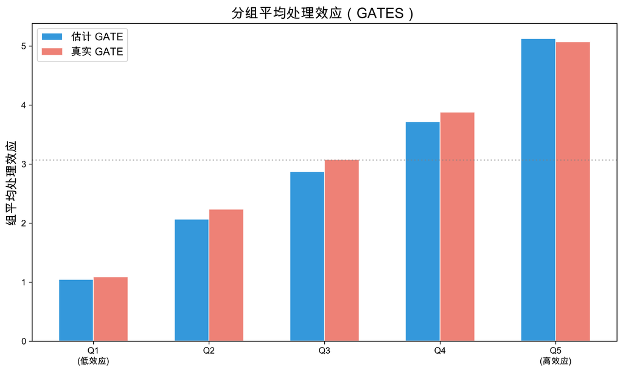

```python
fig, ax = plt.subplots(figsize=(10, 6))
order = np.argsort(tau_hat)
n_groups = 5
effects, true_effs, group_labels = [], [], []

for g in range(n_groups):
    idx = order[g * n_te // n_groups:(g + 1) * n_te // n_groups]
    # 简单差分估计（随机实验下无偏）
    effect_est = Y_te[idx][T_te[idx]==1].mean() - Y_te[idx][T_te[idx]==0].mean()
    true_eff = np.mean(tau_true_te[idx])
    effects.append(effect_est)
    true_effs.append(true_eff)
    if g == 0:
        group_labels.append(f'Q1\n(低效应)')
    elif g == 4:
        group_labels.append(f'Q5\n(高效应)')
    else:
        group_labels.append(f'Q{g+1}')

x_pos = np.arange(n_groups)
ax.bar(x_pos - 0.15, effects, 0.3, color='#3498db', label='估计 GATE', edgecolor='white')
ax.bar(x_pos + 0.15, true_effs, 0.3, color='#e74c3c', alpha=0.7, label='真实 GATE', edgecolor='white')
ax.set_xticks(x_pos)
ax.set_xticklabels(group_labels)
ax.set_ylabel('组平均处理效应', fontsize=14)
ax.set_title('分组平均处理效应（GATES）', fontsize=16, fontweight='bold')
ax.legend(fontsize=12)
ax.axhline(np.mean(tau_true_te), color='gray', ls=':', alpha=0.5, label='ATE')
plt.tight_layout()
plt.show()
```

### 3.4.4 GATES 结果解读

- **蓝色条形**：基于实验数据的差分估计，反映每个五分位组中被处理者和未被处理者结果的差异
- **红色条形**：真实 GATE（在模拟中已知），用于验证估计的准确性
- 从 Q1 到 Q5 的递增趋势清晰表明异质性是真实的
- Q1 和 Q5 之间的差距越大，异质性越强

**注记BLP vs GATES**

BLP 给出一个 p-value，回答”异质性是否存在”的二元问题。GATES 通过可视化回答”异质性有多大、模式是什么”的更丰富问题。两者互补使用效果最佳。

# 4 第三部分：效应排序评估——TOC 与 Qini

## 4.1 处理优先级问题

在确认异质性真实存在之后，下一个问题是：*我们的 CATE 模型排序得有多好？*

假设你有两个 CATE 模型（例如因果森林 vs X-Learner），两者都通过了 BLP 检验。你需要比较它们的排序质量——哪个模型更好地识别了谁应该优先接受处理。

### 4.1.1 为什么需要专门的排序评估

这个问题与预测建模的评估有本质区别：

- 在预测建模中，我们直接比较 $\hat{y}$ 和 $y$，计算 MSE 或 AUC
- 在因果建模中，*真实的个体处理效应 $\tau_i = Y_i(1) - Y_i(0)$ 是不可观测的*
- 因此我们无法计算 $|\hat{\tau}(x_i) - \tau_i|$ 的均值

一个关键洞察是：对于政策制定而言，我们不需要 $\hat{\tau}(x)$ 的绝对值准确，只需要 *排序正确*。即使 $\hat{\tau}(x)$ 在尺度上有系统性偏差，只要它正确识别了”谁的效应大、谁的效应小”，就足以支撑好的政策决策。

## 4.2 TOC 曲线

处理操作特征曲线（Treatment Operating Characteristic, TOC）由 Yadlowsky et al. (2021) 系统化提出。

### 4.2.1 定义

按 $\hat{\tau}(x)$ 从高到低排序，计算 *top-$q$ 人群* 的平均处理效应：

$$\text{TOC}(q) = E[\tau(X) \mid \hat{\tau}(X) \geq \hat{\tau}_{1-q}]$$

其中 $\hat{\tau}_{1-q}$ 是 $\hat{\tau}(x)$ 分布的 $(1-q)$ 分位数。

### 4.2.2 解读

- **横轴**：目标人群比例 $q$（从 0% 到 100%）
- **纵轴**：被选中人群的平均处理效应
- **理想曲线**：从高处开始（最受益的人），随 $q$ 增大逐渐下降
- **极端情况**：$q = 0^+$ 时 TOC 接近最大单体效应；$q = 1$ 时 TOC = ATE

一个好的 CATE 模型的 TOC 曲线应当在小 $q$ 处远高于 ATE，说明模型成功识别了最受益的群体。

## 4.3 AUTOC 与 RATE 框架

### 4.3.1 AUTOC

TOC 曲线下面积（Area Under the TOC）定义为：

$$\text{AUTOC} = \int_0^1 [\text{TOC}(q) - \text{ATE}] \, dq$$

AUTOC 衡量模型的排序能力优于随机分配的整体程度。AUTOC = 0 意味着模型的排序与随机无异。

### 4.3.2 RATE 框架

AUTOC 是更一般的 RATE（Rank-Weighted Average Treatment Effects）框架的特例：

$$\text{RATE}(\hat{\tau}, \omega) = \int_0^1 \text{TOC}(q) \cdot \omega(q) \, dq$$

通过选择不同的权重函数 $\omega(q)$，可以得到不同的评估指标：

[output not shown]

## 4.4 Qini 曲线

### 4.4.1 定义

按 $\hat{\tau}(x)$ 从高到低排序，绘制累积增益：

$$\text{Qini}(q) = q \cdot [\text{TOC}(q) - \text{ATE}]$$

Qini 曲线衡量的是：相比于随机分配同样比例的人群，按模型排序能额外获得多少增益。

### 4.4.2 Qini 系数解读

| Qini 系数 | 含义 |
| --- | --- |
| Qini > 0 | 模型排序优于随机分配 |
| Qini $\approx$ 0 | 模型的排序与随机无异 |
| Qini 越大 | 排序效果越好 |

Qini 曲线和 Qini 系数在营销领域（uplift modeling）有着广泛的应用历史，Radcliffe & Surry (2011) 是经典参考文献。

## 4.5 Python 实现：TOC 与 Qini 曲线

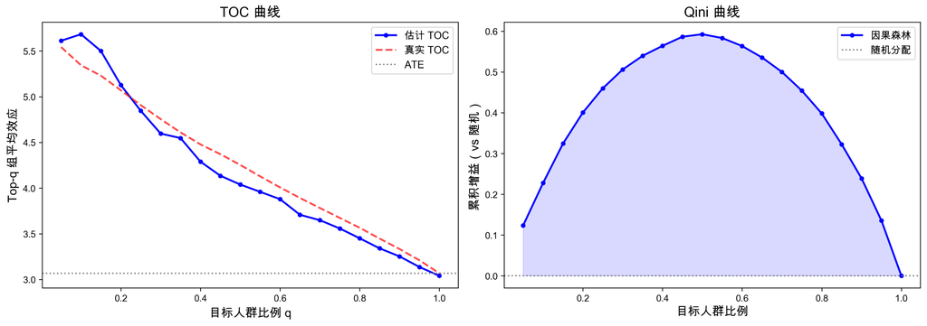

```
AUTOC (排序增益面积):  1.104
Qini 系数:             0.400
```

```python
fig, axes = plt.subplots(1, 2, figsize=(14, 5))
sorted_idx = np.argsort(-tau_hat)

# 左图：TOC 曲线
fracs = np.linspace(0.05, 1.0, 20)
toc_est, toc_true = [], []
for q in fracs:
    k = int(q * n_te)
    idx = sorted_idx[:k]
    toc_est.append(Y_te[idx][T_te[idx]==1].mean() - Y_te[idx][T_te[idx]==0].mean())
    toc_true.append(np.mean(tau_true_te[idx]))

axes[0].plot(fracs, toc_est, 'b-o', ms=4, lw=2, label='估计 TOC')
axes[0].plot(fracs, toc_true, 'r--', lw=2, alpha=0.7, label='真实 TOC')
axes[0].axhline(np.mean(tau_true_te), color='gray', ls=':', label='ATE')
axes[0].set_xlabel('目标人群比例 q', fontsize=13)
axes[0].set_ylabel('Top-q 组平均效应', fontsize=13)
axes[0].set_title('TOC 曲线', fontsize=15, fontweight='bold')
axes[0].legend(fontsize=11)

# 右图：Qini 曲线
ate = np.mean(tau_true_te)
qini_vals = [q * (t - ate) for q, t in zip(fracs, toc_true)]
axes[1].plot(fracs, qini_vals, 'b-o', ms=4, lw=2, label='因果森林')
axes[1].axhline(0, color='gray', ls=':', label='随机分配')
axes[1].fill_between(fracs, 0, qini_vals, alpha=0.15, color='blue')
axes[1].set_xlabel('目标人群比例', fontsize=13)
axes[1].set_ylabel('累积增益（vs 随机）', fontsize=13)
axes[1].set_title('Qini 曲线', fontsize=15, fontweight='bold')
axes[1].legend(fontsize=11)
plt.tight_layout()
plt.show()

# 计算 AUTOC 和 Qini 系数
autoc = np.trapz([t - ate for t in toc_true], fracs)
qini_coef = np.trapz(qini_vals, fracs)
print(f"AUTOC (排序增益面积):  {autoc:.3f}")
print(f"Qini 系数:             {qini_coef:.3f}")
```

### 4.5.2 Qini 曲线解读

- 正值区域（蓝色填充）表示模型优于随机分配
- 面积越大，排序质量越高
- 如果曲线出现负值区域，说明模型在某个比例段的排序甚至不如随机

## 4.6 评估指标对比

| 指标 | 衡量内容 | 适用场景 | 是否需要样本分割 |
| --- | --- | --- | --- |
| BLP $\alpha_1$ | 异质性是否真实存在 | 初步验证，单模型 | 是 |
| GATES | 各组效应的梯度 | 可视化异质性强度 | 是 |
| AUTOC | 排序整体优劣 | 模型间比较 | 是 |
| Qini 系数 | 高优先级排序质量 | 预算受限的场景 | 是 |

**警告所有指标都需要样本分割**

在训练集上估计 CATE，在独立的测试集上评估。否则过拟合会让任何模型看起来都很好。这一原则贯穿本讲的所有方法。

# 5 第四部分：变量重要性分析

## 5.1 识别异质性的驱动因素

在确认异质性存在并评估了排序质量之后，一个自然的问题是：*哪些特征驱动了处理效应的差异？*

因果森林的变量重要性（variable importance）提供了一个系统化的答案。它衡量每个特征对 CATE 变异的贡献程度。

### 5.1.1 两种计算方法

**方法一：分裂频率法**

统计因果森林中每个变量被选为分裂变量的频率。频率越高的变量对 CATE 的异质性贡献越大。在 `grf` 包中，`variable_importance()` 函数直接返回这个指标。

**方法二：代理模型法**

训练一个梯度提升模型来学习 $\hat{\tau}(x)$，然后提取该模型的特征重要性。这种方法不依赖因果森林内部的分裂结构，可以作为交叉验证的手段。

两种方法衡量的都是同一件事：每个特征对 *预测异质性的贡献*。

## 5.2 Python 实现：变量重要性

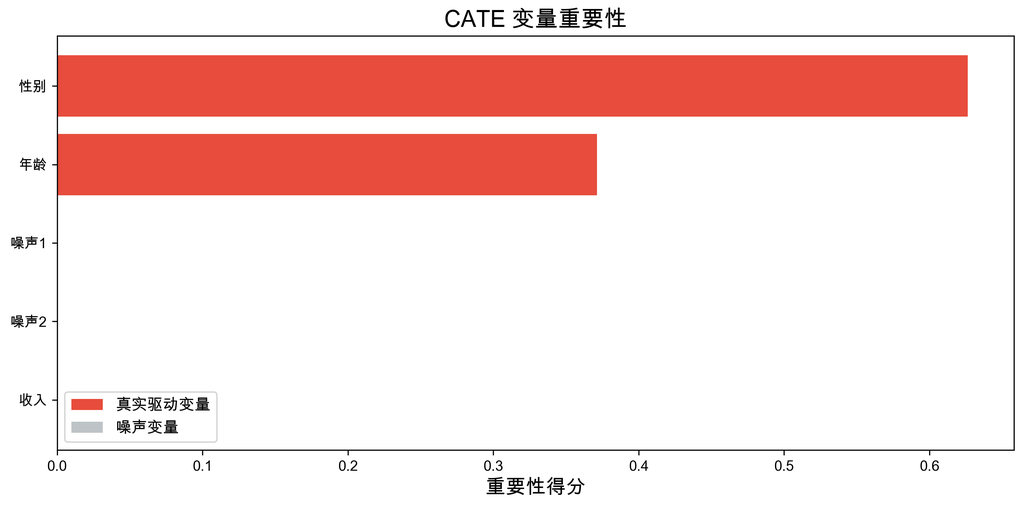

```
各变量重要性得分:
  ★ 性别: 0.627
  ★ 年龄: 0.372
    噪声1: 0.001
    噪声2: 0.001
    收入: 0.000
```

```python
# 代理模型法：用 GBRT 学习 CATE → 提取特征重要性
surrogate = GradientBoostingRegressor(
    n_estimators=200, max_depth=3, random_state=42
)
surrogate.fit(X_te, tau_hat)
importances = surrogate.feature_importances_

fig, ax = plt.subplots(figsize=(10, 5))
sorted_imp = np.argsort(importances)
colors = ['#e74c3c' if feature_names[i] in ['年龄', '性别']
          else '#bdc3c7' for i in sorted_imp]
ax.barh(range(len(importances)), importances[sorted_imp],
        color=colors, edgecolor='white')
ax.set_yticks(range(len(importances)))
ax.set_yticklabels([feature_names[i] for i in sorted_imp])
ax.set_xlabel('重要性得分', fontsize=14)
ax.set_title('CATE 变量重要性', fontsize=16, fontweight='bold')

# 添加图例
from matplotlib.patches import Patch
legend_elements = [Patch(facecolor='#e74c3c', label='真实驱动变量'),
                   Patch(facecolor='#bdc3c7', label='噪声变量')]
ax.legend(handles=legend_elements, fontsize=11)
plt.tight_layout()
plt.show()

print("各变量重要性得分:")
for i in sorted_imp[::-1]:
    marker = "★" if feature_names[i] in ['年龄', '性别'] else " "
    print(f"  {marker} {feature_names[i]}: {importances[i]:.3f}")
```

### 5.2.1 结果解读

在我们的模拟中，真实的 CATE 为 $\tau(x) = 2 + x_0 + 2x_1$，其中 $x_0$（年龄）和 $x_1$（性别）是唯一的驱动因素。变量重要性分析应当将这两个变量排在前两位，而噪声变量（收入、噪声 1、噪声 2）的重要性接近零。

## 5.3 变量重要性 $\neq$ 因果关系

**警告重要区分**

变量重要性回答的是”哪些特征 *预测* 了异质性”，而非”哪些特征 *导致* 了异质性”。两者有本质区别。

**为什么不是因果关系？**

- 年龄的重要性高 $\neq$ 年龄导致了处理效应的差异
- 可能是年龄与某个未观测的真正调节变量（例如学习动机）高度相关
- 如果年龄只是代理变量（proxy），基于年龄进行干预分配可能无效

**最佳实践**

1. 将变量重要性作为 *假设生成* 的起点，而非结论
2. 结合 *领域知识* 对结果进行验证和解释
3. 如果需要因果性的调节效应分析，应使用更严格的框架（例如 causal mediation analysis）

## 5.4 R 实现参考

在 R 的 `grf` 包中，变量重要性的获取非常直接：

```r
library(grf)

# 训练因果森林
cf <- causal_forest(X, Y, W)

# 变量重要性（分裂频率法）
var_imp <- variable_importance(cf)
names(var_imp) <- colnames(X)
sort(var_imp, decreasing = TRUE)
```

`grf` 包的 `variable_importance()` 直接返回标准化的分裂频率，无需额外步骤。

# 6 第五部分：政策树与政策学习

## 6.1 从 CATE 到最优决策

到目前为止，我们已经完成了 CATE 的估计、检验和评估。最后一步也是最重要的一步：*将 CATE 估计转化为可执行的政策决策*。

### 6.1.1 政策制定的核心问题

回到就业培训的例子：你已经估计了每个人的 $\hat{\tau}(x)$，通过 BLP 检验确认异质性真实存在，Qini 曲线显示模型排序质量良好。现在的问题是：

**注记预算约束下的分配问题**

培训预算只够覆盖 50% 的申请者。如何设计分配规则 $\pi(x) \in \{0, 1\}$，使得社会福利最大化？

### 6.1.2 朴素方案 vs 政策学习

**朴素方案**：按 $\hat{\tau}(x)$ 从高到低排序，选取 top-50%。

- 优点：简单、直接利用 CATE 估计
- 缺点：规则不透明，无法向决策者解释”为什么选这些人”
- 问题：$\hat{\tau}(x)$ 的绝对值可能有偏差，排序可能不够稳健

**政策学习方案**：学习一棵简单的决策树，给出可解释的分配规则。

- 优点：规则透明、可审计、便于向非技术决策者解释
- 输出形式：例如”年龄 $\leq$ 30 且未就业 → 分配培训”

## 6.2 政策学习的形式化

### 6.2.1 最优分配问题

寻找政策规则 $\pi: \mathcal{X} \to \{0, 1\}$，最大化社会福利：

$$\pi^* = \arg\max_{\pi \in \Pi} E[\tau(X) \cdot \pi(X)]$$

如果有预算约束 $E[\pi(X)] \leq B$，则成为约束优化问题。

### 6.2.2 估计社会福利

由于 $\tau(X)$ 不可直接观测，Athey & Wager (2021) 提出使用 AIPW (Augmented Inverse Propensity Weighting) 得分作为 $\tau(X)$ 的替代：

$$\hat{\Gamma}_i = \hat{\mu}_1(X_i) - \hat{\mu}_0(X_i) + \frac{D_i (Y_i - \hat{\mu}_1(X_i))}{e(X_i)} - \frac{(1-D_i)(Y_i - \hat{\mu}_0(X_i))}{1 - e(X_i)}$$

**注记AIPW 得分的优越性**

- $\hat{\Gamma}_i$ 是 $\tau(X_i)$ 的无偏个体级估计
- 对 $\hat{\Gamma}_i$ 求加权平均直接给出社会福利的无偏估计
- **双重稳健性**：即使倾向得分模型 $\hat{e}(x)$ 或结果模型 $\hat{\mu}_d(x)$ 之一有偏差，AIPW 得分仍然一致

这样，最优政策问题变为：

$$\pi^* = \arg\max_{\pi \in \Pi} \frac{1}{n} \sum_{i=1}^{n} \hat{\Gamma}_i \cdot \pi(X_i)$$

## 6.3 最优政策树

### 6.3.1 为什么用树

在政策空间 $\Pi$ 的选择上，Athey & Wager (2021) 推荐使用 *深度有限的决策树*：

$$\Pi = \{\text{深度} \leq d \text{ 的决策树}\}$$

限制树的深度确保规则可解释：

| 深度 | 最大叶节点数 | 最大条件数 | 可解释性 |
| --- | --- | --- | --- |
| 1 | 2 | 1 | 极高：一个二分规则 |
| 2 | 4 | 3 | 高：两层简单条件 |
| 3 | 8 | 7 | 中等：三层条件组合 |

### 6.3.2 实现步骤

1. 计算 AIPW 得分 $\hat{\Gamma}_i$（或近似使用 $\hat{\tau}(X_i)$）
2. 搜索使 $\sum \hat{\Gamma}_i \cdot \pi(X_i)$ 最大的深度-$d$ 树
3. 叶节点中 $\bar{\Gamma} > 0$ → 分配处理；$\bar{\Gamma} \leq 0$ → 不分配

**提示简化实现**

在实际中，可以用 $\hat{\tau}(X_i)$ 代替 AIPW 得分作为拟合政策树的目标。虽然理论上不如 AIPW 得分稳健，但在随机实验的设置下（已知 $e(x)$）差别通常较小。

## 6.4 Python 实现：政策树

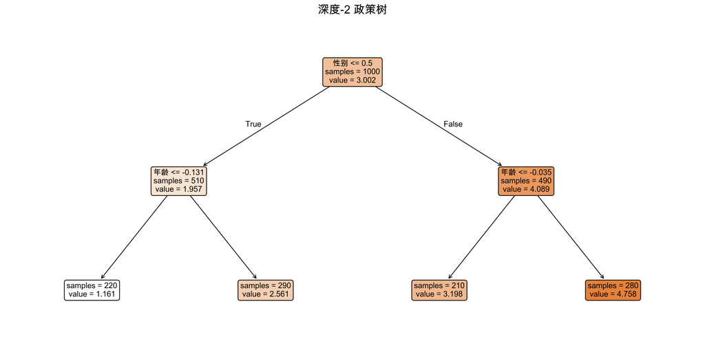

```python
# 深度-2 政策树（基于 CATE 估计）
tree = DecisionTreeRegressor(max_depth=2, random_state=42)
tree.fit(X_te, tau_hat)

fig, ax = plt.subplots(figsize=(14, 7))
plot_tree(tree, feature_names=feature_names, filled=True,
          rounded=True, fontsize=11, ax=ax, impurity=False)
ax.set_title('深度-2 政策树', fontsize=16, fontweight='bold')
plt.tight_layout()
plt.show()
```

### 6.4.1 解读政策树

- **每个叶节点**显示该组的 CATE 预测均值和样本量
- **叶节点值 > 0** → 建议干预（处理效应为正）
- **叶节点值 $\leq$ 0** → 不建议干预
- 分裂条件给出了可解释的分配规则

在我们的模拟中，由于 $\tau(x) = 2 + x_0 + 2x_1$，理想的政策树应当主要基于性别（$x_1$）和年龄（$x_0$）进行分裂。

## 6.5 Python 实现：分配策略比较

下面比较三种不同分配策略在预算约束下的表现：

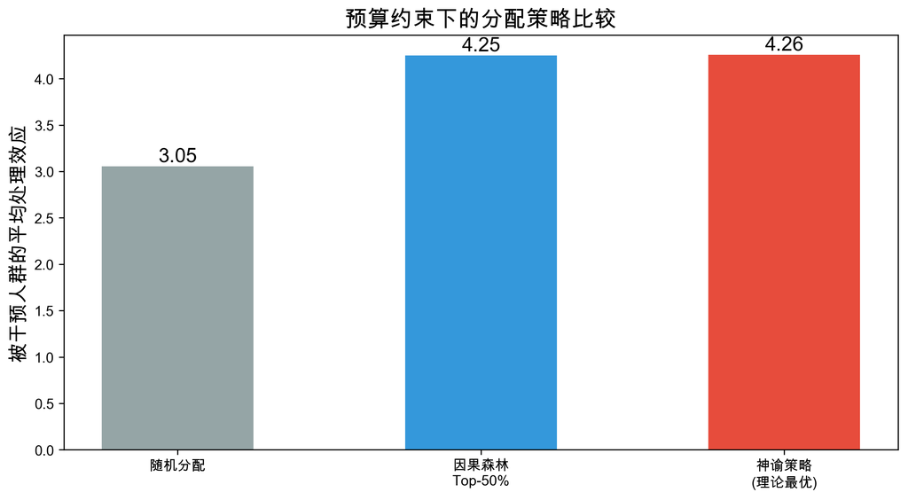

```
==================================================
分配策略比较（预算 = 50%）
==================================================
  随机分配: 平均效应 = 3.055
  因果森林 Top-50%: 平均效应 = 4.250
  神谕策略（理论最优）: 平均效应 = 4.257

因果森林 vs 随机: 提升 1.196
理论最优 vs 随机: 提升 1.202
因果森林效率 = 99%（相对于理论上限）
```

```python
# 预算约束：只能干预 50% 的人群
budget = n_te // 2
np.random.seed(123)
random_idx = np.random.choice(n_te, budget, replace=False)
model_idx = np.argsort(-tau_hat)[:budget]
oracle_idx = np.argsort(-tau_true_te)[:budget]

strats = ['随机分配', '因果森林\nTop-50%', '神谕策略\n(理论最优)']
effs = [np.mean(tau_true_te[random_idx]),
        np.mean(tau_true_te[model_idx]),
        np.mean(tau_true_te[oracle_idx])]

fig, ax = plt.subplots(figsize=(9, 5))
bars = ax.bar(strats, effs, color=['#95a5a6', '#3498db', '#e74c3c'], width=0.5)
for bar, val in zip(bars, effs):
    ax.text(bar.get_x() + bar.get_width()/2, bar.get_height() + 0.05,
            f'{val:.2f}', ha='center', fontsize=14, fontweight='bold')
ax.set_ylabel('被干预人群的平均处理效应', fontsize=14)
ax.set_title('预算约束下的分配策略比较', fontsize=16, fontweight='bold')
plt.tight_layout()
plt.show()

# 详细比较
print("=" * 50)
print("分配策略比较（预算 = 50%）")
print("=" * 50)
for s, e in zip(['随机分配', '因果森林 Top-50%', '神谕策略（理论最优）'], effs):
    print(f"  {s}: 平均效应 = {e:.3f}")
print(f"\n因果森林 vs 随机: 提升 {effs[1] - effs[0]:.3f}")
print(f"理论最优 vs 随机: 提升 {effs[2] - effs[0]:.3f}")
print(f"因果森林效率 = {(effs[1]-effs[0])/(effs[2]-effs[0])*100:.0f}%（相对于理论上限）")
```

### 6.5.1 分配策略比较解读

- **随机分配**：无差别选取 50% 人群，预期平均效应等于 ATE
- **因果森林 Top-50%**：选取 $\hat{\tau}(x)$ 最高的 50% 人群
- **神谕策略**：如果我们知道真实 $\tau(x)$，选取最高的 50%（理论上限）

因果森林策略的效率比例（相对于理论最优的提升百分比）衡量了实际可实现的收益。

## 6.6 政策学习的实践要点

**警告三条核心准则**

**1. 交叉验证福利**

不要在训练政策的数据上评估福利。应当使用独立的验证数据评估政策的期望效果。

**2. 约束要明确**

预算上限、公平性约束、伦理限制都应在政策学习中显式编码。

**3. 简单优先**

优先选择可解释的规则（浅树、线性规则）。复杂的深度决策树虽然可能在训练数据上表现更好，但泛化性和可审计性差。

### 6.6.1 伦理考量

政策学习的应用需要注意以下伦理问题：

- **公平性**：按种族、性别等敏感属性差异化分配可能引发公平性和法律问题
- **历史偏见**：$\hat{\tau}(x)$ 可能反映历史数据中的偏见而非真实因果效应
- **人类监督**：政策学习 $\neq$ 自动决策。算法的建议应当与领域专家的判断结合
- **透明度**：政策规则需要向受影响群体公开，接受公众审查

## 6.7 R 实现参考：policytree

R 的 `policytree` 包（由 Athey 团队开发）提供了最优政策树的原始实现：

```r
library(grf)
library(policytree)

# 1. 估计因果森林
cf <- causal_forest(X_train, Y_train, W_train)

# 2. 计算 AIPW 得分
gamma <- double_robust_scores(cf)

# 3. 训练最优政策树（深度 = 2）
pt <- policy_tree(X_test, gamma[test_idx, ], depth = 2)

# 4. 预测分配
pi <- predict(pt, X_new)  # 返回 1（处理）或 2（不处理）

# 可视化
plot(pt)
```

**提示Python vs R 工具推荐**

- **Python**：`econml.dml.CausalForestDML` + `sklearn.tree.DecisionTreeRegressor`（简易政策树）
- **R**：`grf::causal_forest` + `policytree::policy_tree`（推荐，理论最优实现）
- `policytree` 实现了精确的最优政策树搜索，而 sklearn 的 `DecisionTreeRegressor` 使用贪心分裂，可能不是全局最优

# 7 第六部分：完整工作流总结

## 7.1 从 CATE 到决策的完整管道

本讲介绍的方法构成了一个完整的分析管道：

```
                              ┌──────────────┐
                              │  估计 CATE   │
                              │ （上节课 GRF）│
                              └──────┬───────┘
                                     │
                              ┌──────▼───────┐
                  Step 1      │  BLP 检验    │
               （是否真实？）    │  + GATES     │
                              └──────┬───────┘
                                     │ 如果 α₁ 显著
                              ┌──────▼───────┐
                  Step 2      │  TOC / Qini  │
               （排序多好？）    │  AUTOC 比较   │
                              └──────┬───────┘
                                     │
                     ┌───────────────┼───────────────┐
                     │               │               │
              ┌──────▼──────┐ ┌─────▼──────┐ ┌──────▼──────┐
              │ 变量重要性  │ │  政策树    │ │ 策略比较   │
              │ （哪些特征）│ │ （分配规则）│ │ （福利评估）│
              └─────────────┘ └────────────┘ └─────────────┘
```

### 7.1.1 关键原则

1. **始终先检验**：BLP/GATES 是后续所有分析的前提
2. **始终样本分割**：训练 ↔︎ 评估/决策使用不同数据
3. **排序优先于校准**：绝对值不重要，排序才重要
4. **可解释性约束**：政策树深度 $\leq$ 2-3

## 7.2 推荐工具

### 7.2.1 Python 生态

| 包 | 功能 |
| --- | --- |
| `econml` | CausalForestDML（CATE 估计 + 推断） |
| `causalml` | UpliftTreeClassifier、plot_qini |
| `sklearn` | DecisionTreeRegressor（简易政策树） |

### 7.2.2 R 生态

| 包 | 功能 |
| --- | --- |
| `grf` | causal_forest、best_linear_projection、rank_average_treatment_effect |
| `policytree` | optimal_policy_tree（推荐，原始实现） |
| `uplift` | Qini 曲线绘制 |

# 8 第七部分：练习与思考

### 8.0.1 练习 1：BLP 检验的直觉

假设在一个完全同质的实验中（所有人的处理效应都是 $\tau = 3$），你仍然使用因果森林估计了 $\hat{\tau}(x)$（此时 $\hat{\tau}(x)$ 的变化纯粹来自噪声）。

1. 在 BLP 检验中，$\alpha_0$ 应该等于多少？
2. $\alpha_1$ 的期望值是多少？通过样本分割获得的 $\hat{\alpha}_1$ 是否显著？
3. 如果不做样本分割，直接在训练数据上跑 BLP 回归，$\alpha_1$ 会怎样？

### 8.0.2 练习 2：Qini 曲线的构建

给定以下数据（10 个个体，随机实验），手动绘制 Qini 曲线：

| 个体 | $X_1$ | $T$ | $Y$ | $\hat{\tau}(x)$ |
| --- | --- | --- | --- | --- |
| 1 | 高 | 1 | 8 | 4.2 |
| 2 | 低 | 0 | 3 | 1.1 |
| 3 | 高 | 0 | 4 | 3.8 |
| 4 | 低 | 1 | 5 | 0.9 |
| 5 | 高 | 1 | 9 | 4.5 |
| 6 | 低 | 0 | 2 | 1.3 |
| 7 | 高 | 0 | 5 | 3.5 |
| 8 | 低 | 1 | 4 | 0.7 |
| 9 | 高 | 1 | 7 | 3.9 |
| 10 | 低 | 0 | 3 | 1.0 |

步骤：(a) 按 $\hat{\tau}(x)$ 排序；(b) 计算 ATE；(c) 对 $q = 20\%, 40\%, \ldots, 100\%$，计算 $\text{TOC}(q)$ 和 $\text{Qini}(q) = q \cdot [\text{TOC}(q) - \text{ATE}]$

### 8.0.3 练习 3：政策树设计

你是一家在线教育平台的数据科学家，公司想为用户提供个性化的学习辅导（有预算限制）。已知的特征包括：学习时长、测验成绩、课程完成率、登录频率。

1. 你会如何设计 CATE 估计 → 政策制定的完整管道？
2. 如果政策树的深度限制为 2，最多能产生几种分配策略？
3. 在此场景下，“公平性”约束应如何体现？

### 8.0.4 练习 4：方法选择

对于以下场景，选择最合适的评估工具并解释原因：

1. 一个慈善组织想确认其 microcredit 项目是否对不同收入群体有差异化影响
2. 两个研究团队分别用因果森林和 X-Learner 估计了 CATE，需要比较哪个更好
3. 一家制药公司想基于基因特征为患者制定个性化用药方案

# 9 参考文献

1. Chernozhukov, V., Demirer, M., Duflo, E., & Fernández-Val, I. (2023). Generic Machine Learning Inference on Heterogeneous Treatment Effects in Randomized Experiments. *NBER Working Paper No. 24678*.
2. Yadlowsky, S., Fleming, S., Shah, N., Brunskill, E., & Wager, S. (2021). Evaluating Treatment Prioritization Rules via Rank-Weighted Average Treatment Effects. *arXiv:2111.07966*.
3. Athey, S., & Wager, S. (2021). Policy Learning with Observational Data. *Econometrica*, 89(1), 133–161.
4. Athey, S., & Imbens, G. W. (2016). Recursive Partitioning for Heterogeneous Causal Effects. *Proceedings of the National Academy of Sciences*, 113(27), 7353–7360.
5. Athey, S., Tibshirani, J., & Wager, S. (2019). Generalized Random Forests. *Annals of Statistics*, 47(2), 1148–1178.
6. Radcliffe, N. J., & Surry, P. D. (2011). Real-World Uplift Modelling with Significance-Based Uplift Trees. *Stochastic Solutions White Paper*.
7. Wager, S., & Athey, S. (2018). Estimation and Inference of Heterogeneous Treatment Effects using Random Forests. *Journal of the American Statistical Association*, 113(523), 1228–1242.

# 下节课预告

**第十一讲：双重机器学习——高维控制与去偏估计**

- 朴素 ML 插件估计的偏差问题
- Neyman 正交性：为什么需要”双重”修正
- DML 框架与部分线性模型
- 高维控制变量的因果效应估计

核心思想：当控制变量数量很多时（甚至超过样本量），传统方法失效。*双重机器学习* 通过正交化技巧，让我们在使用 ML 控制混杂的同时得到有效的因果推断。